# Filter Indeterminate JABOT Specimens

This guide explains how to use the `jabot_indets()` function in the `jabotR` package to retrieve occurrence records of indeterminate specimens (e.g., identified only to family or genus level) from the Rio de Janeiro Botanical Garden’s JABOT online managing herbarium collection system.

## Function Overview

`jabot_indets()` is designed to identify and extract plant specimen records from JABOT collections that are not determined to species level. It allows filtering by herbarium, taxon, locality (Brazilian state), year, and taxonomic rank.

This function is especially useful for identifying possible Linnean shortfalls by summarizing the amount of undetermined taxa across different herbaria or within a particular plant family. It helps researchers pinpoint data gaps in plant identification within JABOT.

## Arguments

[output not shown]

## Use Case: Retrieve All Indeterminates by Family

```r
jabot_indets(
  level = "FAMILY",
  verbose = TRUE,
  save = TRUE,
  dir = "jabot_indets",
  filename = "family_level_indets"
)
```

## Filter by Herbarium and State

```r
jabot_indets(
  taxon = "Fabaceae",
  herbarium = "RB",
  state = c("BA", "MG"),
  recordYear = c("1990", "2022")
)
```

## Filtering by Taxonomic Rank and Year

```r
jabot_indets(
  level = "GENUS",
  recordYear = "2020",
  save = FALSE
)
```

## Analyzing a Specific Dataset

You can reuse previously downloaded JABOT data by setting the `path` argument:

```r
jabot_indets(
  path = "my_jabot_data",
  updates = FALSE,
  verbose = TRUE
)
```

### Why Use `path`?

- It allows working **offline** with already downloaded JABOT archives.
- It avoids **redundant downloads**, speeding up analysis.
- It improves **reproducibility** by analyzing a specific static dataset.
- Set `updates = FALSE` to avoid modifying your local data.
- It is ideal when working with a **shared folder** or preserving **frozen datasets**.

## Use Case: Linnean Shortfalls Insight

By summarizing undetermined records across herbaria or within a taxon, `jabot_indets()` serves as a powerful diagnostic tool to highlight data gaps in floristic knowledge. It can help researchers:

- Visualize how many specimens are unidentified across collections.
- Prioritize taxonomic work on poorly determined groups.
- Highlight herbaria with the highest volume of unidentified material.

## Visualizing Indeterminates per Herbarium

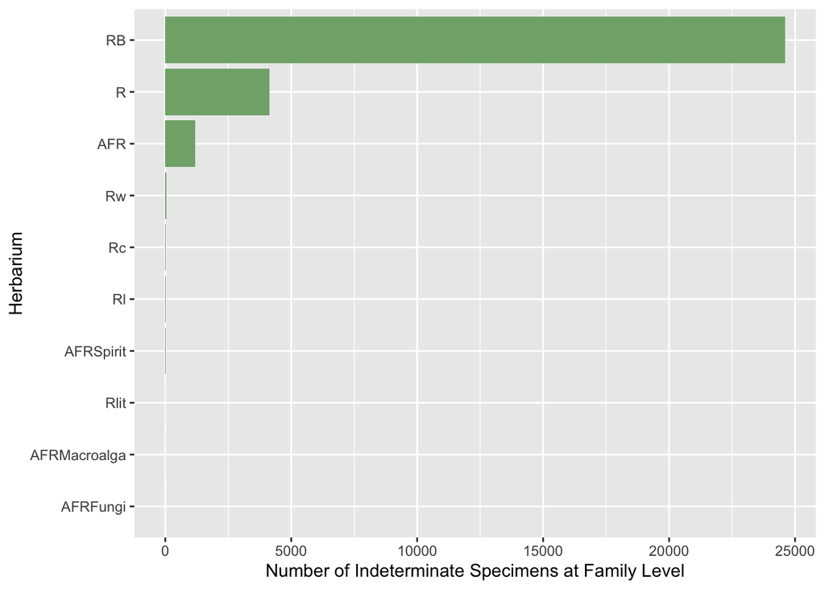

```r
library(dplyr)
library(ggplot2)

results <- jabot_indets(level = "FAMILY",
                          herbarium = c("AFR", "R", "RB"),
                          save = FALSE)

results %>%
  count(collectionCode) %>%
  ggplot(aes(x = reorder(collectionCode, n), y = n)) +
  geom_col() +
  coord_flip() +
  labs(x = "Herbarium",
       y = "Number of Indeterminate Specimens at Family Level")
```

## Tips

- Use `jabot_summary()` to inspect available collections.
- For reproducibility, document your input parameters.
- Logs and CSV files are saved automatically if `save = TRUE`.

## See Also

- `jabot_download()`: Download JABOT specimen records
- `jabot_parse()`: Parse JABOT archive files
- `jabot_summary()`: Summarize JABOT collections